# HW 2: Exploring the Student-Teacher Achievement Ratio Study

POG230

Stefanie Baxter

2022-10-22

# Instructions

You will be required to complete this homework assignment in RStudio as an R Markdown (.rmd) file. When it is completed, please upload the assignment to the corresponding folder in D2L in TWO formats: an .rmd file and a “knitted” file that is either in .pdf, .html, or .doc format. Your TA will review how to do these things with you in lab.

For each sub-question, please write your answer using numbers and prose using text following each prompt and show your work (i.e., your code) in the R chunk provided below each prompt. If the prompt does not require new code (you can obtain the answer from the code you typed for the previous question), you may write `#see above` in the R chunk for that prompt. Your TA will review how to do this with you in lab.

# Some Tips

- Recall that there is more than one way to compute the same thing in R (just like there is more than one way to communicate the same thing in any language). You may use the textbook, labs, and Q&A sessions with your TA to work through each problem.
- For some problems, you will be asked to correct existing code. For these problems, correct the code provided in the R chunk and state in prose what you did to fix the code.
- You are advised to START EARLY on each homework. Do not be discouraged by getting stuck. Learning R and statistics requires trial, error, and support. However, you will not have time to work through the assignment successfully if you start it the night before the due date.

# About the STAR Study and Dataset

The STAR (Student-Teacher Achievement Ratio) Project is a four year examining the effect of class size in early grade levels on educational performance and personal development.

This exercise is adapted from Imai and Webb’s and is in part based on: Mosteller, Frederick. 1997. “The Tennessee Study of Class Size in the EArly School Grades.” 50(7): 14-25.

A longitudinal study is one in which the same participants are followed over time. This particular study lasted from 1985 to 1989 and involved more than 11,000 students. During the four years of the study, students were randomly assigned to small class, regular-sized classes, or regular-sized classes with an aid. In all, the experiment cost around $12 million. Even though the program stopped in 1989 after the first kindergarten class in the program finished third grade, collection of various measurements (e.g., performance on tests in eighth grade, overall high school GPA) continued through the end of participants’ high school attendance.

We will analyze just a portion of this data to investigate whether the small class sizes improved performance or not. The data file name is `STAR.csv`, which is a CSV data file. The names and descriptions of variables in this data set are:

| Name | Description |
| --- | --- |
| `race` | Student’s race (White = 1, Black = 2, Asian = 3, Hispanic = 4, Native American = 5, Others = 6) |
| `classtype` | Type of kindergarten class (small = 1, regular = 2, regular with aid = 3) |
| `g4math` | Total scaled score for math portion of fourth grade standardized test |
| `g4reading` | Total scaled score for reading portion of fourth grade standardized test |
| `yearssmall` | Number of years in small classes |
| `hsgrad` | High school graduation (did graduate = 1, did not graduate = 0) |

Note that there are a fair amount of missing values in this data set. For example, missing values arise because some students left a STAR school before third grade or did not enter a STAR school until first grade.

# Question 1

- 1. How many variables are there? How many observations?

```r
dim(star) # print dimensions
```

```
## [1] 6325    6
```

There are 6 variables (which correspond to the columns), and 6325 observations (which correspond to rows).

- 2. Identify the main treatment variable and outcome variable(s) of the study.

The main treatment variable is the class size because it is the key difference in the the groups being studied. According to the given summary of the study, the treatment has 3 levels; small class, regular size class (this would be the control group), and regular size class with an aid.

- 3. Below, you will see a new factor variable has been added to the data frame called `kinder`. This variable recodes `classtype` by changing integer values to their corresponding informative labels (e.g., change `1` to `small`, etc.). What is a `factor` variable, and how does it differ from a `numeric` or `continuous` variable? How many levels does the factor variable `kinder` have?

A factor variable is one used to categorize and store our data. Thus every observation will fall into a certain category (factor) based on, in this case, class size. Numeric variables on the other hand are continuous since they can take on any value and vary for each observation. Even though this data set only used numbers 1-3 to classify the class sizes as a numeric variable, converting it to a factor makes it much easier to analyze. Our new factor variable has 3 levels (regular, regular with aid, and small) which correspond to the kinder. We can verify this by doing as follows using levels():

```r
star <- mutate(star,
               kinder = factor(if_else(classtype == 1, "small", # if class type = 1, assign it to small
                                       if_else(classtype == 2, "regular", "regular with aid"))))
# if class type = 2, assign it to regular, else assign it to regular with aid (class type 3)

levels(star$kinder) # verify the levels are what we want
```

```
## [1] "regular"          "regular with aid" "small"
```

- 4. Taking part c as your guide, recode the `race` variable into a factor variable with four levels: `white, black, hispanic,` and `others`. For this `race` variable, overwrite the original variable in the data frame rather than creating a new one.

```r
star <-mutate(star,
              race=factor(if_else(race==1, "white",
                                       if_else(race==2, "black",
                                               if_else(race==4,"hispanic","other")))))
levels(star$race) # verify levels()
```

```
## [1] "black"    "hispanic" "other"    "white"
```

- 5. Finally, add a new variable to the dataset called `minority` that has two values: `minority` and `white`. What kind of variable is this, which only has two values?

A variable with only two values is a binary variable.

```r
star<- mutate(star, # create new binary minority variable
              minority=factor(if_else(race=="white", "white","minority")))
# using data from our race variable, if race=white then assign it to white, else assign it to minority
```

- 6. Obtain a summary of your updated dataset. How many variables are there now? How many students are minorities in the dataset? What proportion of students are minorities in the dataset (excluding missing values)?

```r
dim(star) # print new dimensions
```

```
## [1] 6325    8
```

```r
summary(star)  # print summary
```

```
##        race        classtype       yearssmall         hsgrad
##  black   :2058   Min.   :1.000   Min.   :0.0000   Min.   :0.000
##  hispanic:   5   1st Qu.:1.000   1st Qu.:0.0000   1st Qu.:1.000
##  other   :  25   Median :2.000   Median :0.0000   Median :1.000
##  white   :4234   Mean   :2.052   Mean   :0.9542   Mean   :0.833
##  NA's    :   3   3rd Qu.:3.000   3rd Qu.:2.0000   3rd Qu.:1.000
##                  Max.   :3.000   Max.   :4.0000   Max.   :1.000
##                                                   NA's   :3278
##      g4math        g4reading                  kinder         minority
##  Min.   :487.0   Min.   :528.0   regular         :2194   minority:2088
##  1st Qu.:688.0   1st Qu.:696.0   regular with aid:2231   white   :4234
##  Median :710.0   Median :723.0   small           :1900   NA's    :   3
##  Mean   :708.8   Mean   :721.2
##  3rd Qu.:732.5   3rd Qu.:750.0
##  Max.   :821.0   Max.   :836.0
##  NA's   :3930    NA's   :3972
```

There are now 8 variables because we added kinder and minority. From our summary table for the minority variable, excluding NAs, the proportion of minorities is 2088/(2088+4234) = 0.3303.

# Question 2

How does performance on grade 4 reading and math tests vary for students across the three treatment groups? Taking regular-sized classes (without an aid) as the baseline, do students in smaller classes perform better? How about students in regular-sized classes with an aid? In this problem, you will conduct difference of means tests to answer these questions.

- 1. The code below creates a new `tibble` called `g4reading_by_treatment` that breaks down the mean reading score (`g4reading`) for students by treatment group (`kinder`). Notice that the function `filter(!is.na(g4reading))` filters out missing data on this outcome variable. Please run the code and comment on the results in the table.

```r
g4reading_by_treatment <- star %>% # new variable assignment
  filter(!is.na(g4reading)) %>% # filter NAs
  group_by(kinder) %>% # group the data into their respective kinders
  summarize(g4reading_mean = mean(g4reading)) # summarize the means

g4reading_by_treatment # print what we just found
```

```
## # A tibble: 3 × 2
##   kinder           g4reading_mean
##   <fct>                     <dbl>
## 1 regular                    720.
## 2 regular with aid           721.
## 3 small                      723.
```

The g4 reading means are all extremely similar which is interesting. It does make sense that the small class has the highest reading mean, followed by the regular class with aid, and lastly the regular class. However, they only vary by a point or two. Considering that this data set, especially this variable, has a lot of missing data (3972 NAs/6325 observations, almost 63%), it’s possible that there is some bias and we are unable to see the true correlation between the treatment (class size) and the outcome (in this case, grade 4 reading average). For example, it’s possible that there are more NAs in a specific level of the kinder variable (class size), which lowers the sample size and could possibly skew the data.

- 2. The code below creates a new `tibble` called `g4reading_diffs` that uses `g4reading_by_treatment` to create a table listing the difference of means between treatment groups. Taking `regular` as the baseline, it computes the difference in means between (1) `regular` and `small`, and (2) `regular` and `regular with aid`. Please run the code and comment on the results. (You can also examine the code on pp. 63-64 in QSS to see how this difference in means `tibble` is created.)

```r
g4reading_diffs <- g4reading_by_treatment %>% # new variable assignment
  pivot_wider(names_from = kinder, # take names from the kinder variable (3 class types) to categorize
              values_from = g4reading_mean) %>% # take the values from the g4 reading mean
  mutate(diff_regular_with_aid = `regular with aid` - regular, # new variable will calculate difference in means between regular w aid and regular, using values from g4 reading mean for the kinders we are looking at here
         diff_small = small - regular) %>% # do the same for difference of mean of small - regular
  select(diff_regular_with_aid, diff_small) # select the two variables we want to see

g4reading_diffs # print them
```

```
## # A tibble: 1 × 2
##   diff_regular_with_aid diff_small
##                   <dbl>      <dbl>
## 1                 0.826       3.50
```

We can see that the difference in means between the regular sized class and the regular sized class with aid is 0.826, and the difference in means between the regular and small sized classes is 3.50. Since we cannot observe the counter-factual outcome, the difference in means estimator is our best bet at estimating the S.A.T.E, given the assumption of randomization and a large sample size. These numbers indicate that a small class is more ideal for a higher g4 reading score, since the difference in means is higher than that with the regular with aid class (a 2.674 difference between the two), i.e having a smaller class size makes a more significant impact in the g4 reading score. Having a regular sized class with aid still helps with a better g4 reading score, which is to be expected, but the difference is not as large.

- 3. Similar to part (a) above, create a new `tibble` called `g4reading_by_minority` that breaks down the mean reading score (`g4reading`) for students by white vs minority group (`minority`). Label the mean reading score `g4reading_mean_minority`. Use the function `filter(!is.na(g4reading))` to filter out missing data on this outcome variable. Print the table and comment on the results, comparing them with the results from part (a).

```r
g4reading_by_minority <- star %>% # new variable assignment
  filter(!is.na(g4reading)) %>% # filter out missing data
  group_by(minority) %>% # group by minority group (minority, white)
  summarize(g4reading_mean_minority = mean(g4reading)) # summarize the mean

g4reading_by_minority # print
```

```
## # A tibble: 2 × 2
##   minority g4reading_mean_minority
##   <fct>                      <dbl>
## 1 minority                    694.
## 2 white                       726.
```

We can see that the g4 reading mean for white students is 726 whereas the g4 reading mean for minority students is 694. This is a significantly larger difference than what we saw in part a). The g4 reading mean by kinder only varied by a point or two, whereas the mean between white and minority students varies by 32 points.

- 4. Similar to part (b) above, create a new `tibble` called `g4reading_diffs_minority` that uses `g4reading_by_minority` to create a table listing the difference of means between white and minority groups. Taking `white` as the baseline, compute the difference in means between `white` and `minority`. Print the table and comment on the results, comparing them with the results from part (b).

```r
g4reading_diffs_minority <- g4reading_by_minority %>% # new variable assignment
  pivot_wider(names_from = minority, # take the names (categories) from minority
              values_from = g4reading_mean_minority) %>% # take the values from this variable
  mutate(diff_white_and_minority = minority - white) %>% # compute the difference of means
  select(diff_white_and_minority) # select the variable we want

g4reading_diffs_minority # print it
```

```
## # A tibble: 1 × 1
##   diff_white_and_minority
##                     <dbl>
## 1                   -31.7
```

We see that the difference in means for g4 reading scores between white and minority students is 31.7 points, where the minority group is the one with the lower score. As we saw in part c), there is a greater difference in reading scores when we examine white and minority students vs when we look at class size alone. In part b), we saw that there was indeed a difference in mean indicating that a smaller class size yielded higher reading scores, however the difference when we look at our minority variable is much more significant.

- 5. Consider your previous comparisons of the difference in means across treatment groups (based on class size and the presence of an aid) and across race-based groups (minority vs white). What is the key difference between these comparisons when making conclusions about causal inference? (Hint: think about whether the independent variable is randomly assigned or not.)

They difference is that class types were randomly assigned, however race was not. Selection bias could also be a concern when analyzing the race data. Participants obviously cannot be assigned race at random, and their race can predispose them to certain outcomes. Minorities tend to have different socioeconomic conditions than white people which could have a large impact on their education and performance in school. In this case, race is a source of confounding bias and raises concern regarding internal validity.

# Question 3

This Question will ask you to create a series of plots to visualize and comment on the distribution of one or more variables. Please consult Lab 3 for guidance on R code to obtain these plots. QSS chapter 3, section 3 provides additional guidance.

- 1. Create a bar plot that reflects the proportion of students in the dataset that are white vs. minority. Filter out missing values with the function `filter(!is.na(minority))` before you proceed to the function `ggplot`. Label your x and y axes and give your plot a fitting title. (Hint: look at lab 3 for guidance on coding.) Comment on the results. What kind of variable is this, and how many values does it have?

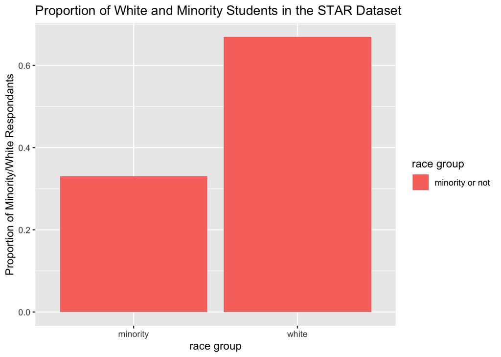

```r
star_reshape= star %>% # new variable assignment
  filter(!is.na(minority)) %>% # filter missing data
  pivot_longer(minority, names_to = "race_group", values_to="proportion") # create a new variable, sending names (categories) from minority to race_group and its values to proportion
star_reshape %>% # take the new variable...
  ggplot(aes(x=as.factor(proportion),color=proportion)) + # take proportion variable from before and make it a factor variable
  geom_bar(aes(y=..prop.., # graphs proportion
               fill=as.factor(race_group), # fill colour by race group even tho it's just one variable so it can be colorful
               group=as.factor(race_group)), # assign values to respective group
           position="dodge") + # don't stack bars, put them side to side
  scale_x_discrete(labels=c("minority", "white")) + # adds labels to x axis categories
  scale_fill_discrete(name="race group", label="minority or not") +
  xlab("race group") + # x axis title
  ylab("Proportion of Minority/White Respondants") + # y axis title
  ggtitle("Proportion of White and Minority Students in the STAR Dataset") # plot title
```

This is a binary variable since we’ve given it two possible values, minority or white. This is also a type of factor variable, since it categorizes data. This bar plot confirms what we learned earlier regarding the proportion of minority students in the data set (0.3303). We see this number in the chart as well, as well as the white respondents with a proportion of 1-0.3303=0.6697.

- 2. Create another bar plot that reflects the proportion of students in the dataset that are in each treatment group (using the variable `kinder`). Label the x and y axes and give your plot a fitting title. What kind of variable is this, and how many values does it have?

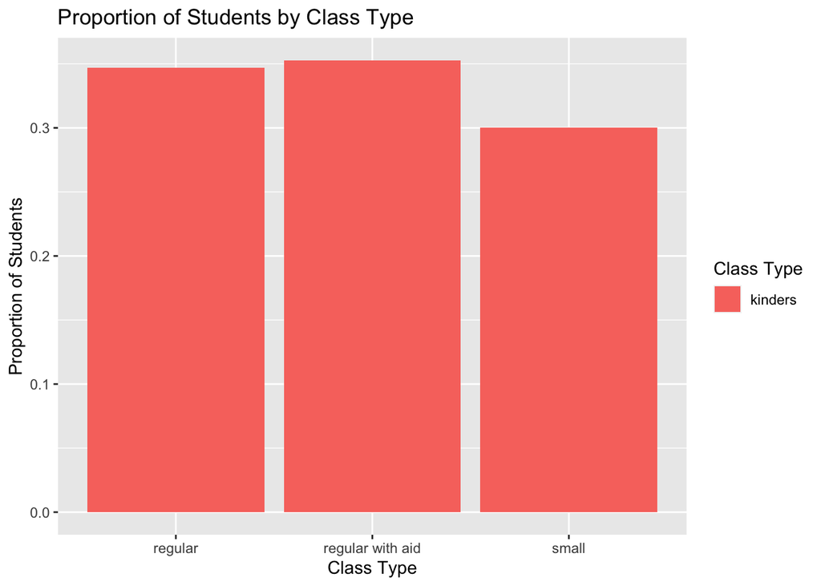

```r
newstar= star %>% # new variable assignment
  pivot_longer(kinder, names_to = "class_type", values_to="proportion") # same logic as before
newstar %>%
  ggplot(aes(x=as.factor(proportion))) + # take proportion variable from before and make it a factor variable
  geom_bar(aes(y=..prop.., # graph proportion
               fill=class_type, # add colour for fun
               group=class_type), # assign values to respective group
           position="dodge") + # don't stack bars, put them side to side
  scale_x_discrete(labels=c("regular", "regular with aid", "small")) + # adds labels to x axis categories
  scale_fill_discrete(name="Class Type", labels="kinders") + # legend
  xlab("Class Type") + # x axis title
  ylab("Proportion of Students") + # y axis title
  ggtitle("Proportion of Students by Class Type") # plot title
```

This is a categorical/factor variable since it categorizes the students by class type. It has 3 values which correspond to the 3 types of class sizes in this study.

- 3. Create a bar plot that reflects the proportion of students in the dataset for each grade 4 reading score. Label the x and y axes and give your plot a fitting title. Comment on the results. Does this look more like a bar plot or a histogram? Why?

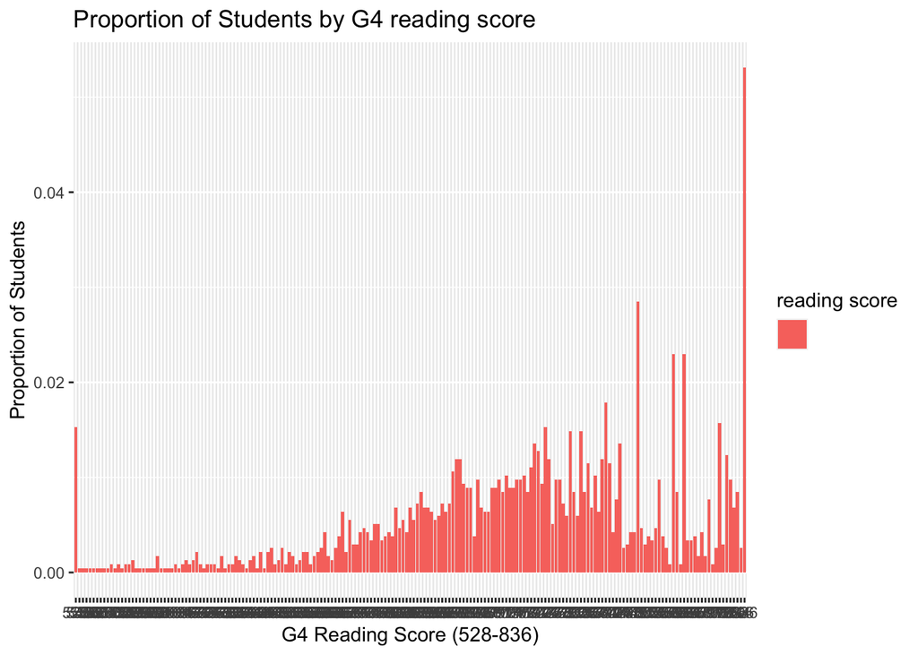

```r
g4readingstar= star %>%
  filter(!is.na(g4reading)) %>%
  pivot_longer(g4reading, names_to = "reading_score", values_to="proportion")
g4readingstar %>%
  ggplot(aes(x=as.factor(proportion))) + # take proportion variable from before and make it a factor variable
  geom_bar(aes(y=..prop.., # graph proportions
               fill=reading_score, # add colour for fun
               group=reading_score), # assign values to respective group
           position="dodge") + # don't stack bars, put them side to side
  scale_fill_discrete(name="reading score", labels='') + # legend
  xlab("G4 Reading Score (528-836)") + # x axis title
  ylab("Proportion of Students") + # y axis title
  ggtitle("Proportion of Students by G4 reading score") # plot title
```

This bar plot allows us to see the variability in g4 reading scores. We can see that a fair amount of students are in the highest category, which is good to see, but it’s difficult to make conclusions about the mean score based on this graph. Although it does have some similarities to a histogram given that there are a lot more bars, it still looks like a bar plot because it is not plotting density and does not help us approximate the distribution of our data. To do this, we should create a histogram which will allow us to better visualize the mean, standard deviation, if our data is normally distributed, amongst other things.

- 4. Now create a histogram for the same variable, grade 4 reading score, setting your binwidth at 10, labeling the x and y axes, and providing a fitting title for the plot. Comment on the results. How does this look different from the bar plot? Why is it a better way of visualizing the distribution of reading scores?

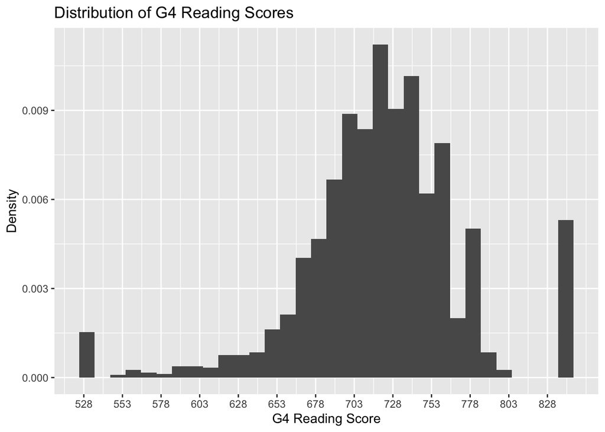

```r
star %>%
  filter(!is.na(g4reading)) %>% # filter missing values
  ggplot(aes(x=g4reading)) + # assign g4reading to x axis
  geom_histogram(aes(y=..density..), # specify that we want a histogram
                 binwidth=10) + # specify binwidth
  scale_x_continuous(breaks=seq(528,836,25)) +  # increments for x axis
  labs(title="Distribution of G4 Reading Scores", y="Density", x="G4 Reading Score") # titles
```

Unlike the bar plot, the histogram allows us to approximate the distribution of the data. By setting bin widths of 10 as apposed to individual reading scores like in the bar plot, we can see that reading scores in the ~700-730 range are the densest (largest number of students fall into this category). The data has a slight negative skew (left skewed) and there are some outliers with perfect reading scores. From this histogram, we could also assume that the standard deviation of our data would be relatively high given that there is a fair amount of dispersion from the mean. All of this should be taken with a grain of salt given the amount of missing data in this category.

- 5. Finally, create a box plot that compares the distribution of reading scores by the treatment variable `kinder`. Label your x and y axes and give your plot an appropriate title. Comment on the results. What can you conclude about the effect of class size on reading performance?

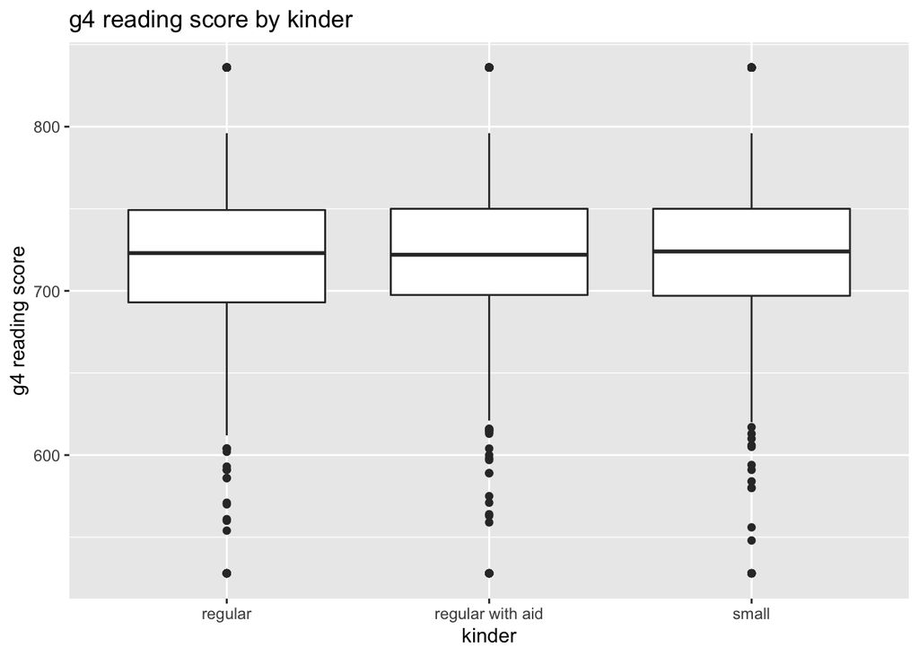

```r
star2 <- star %>%
  filter(!is.na(g4reading)) # filter NA values for plotting purposes

ggplot(star2, aes(y=g4reading, x=kinder)) + # specify axes variables
geom_boxplot()+ # create boxplot
labs(y="g4 reading score", x="kinder", title="g4 reading score by kinder") # titles
```

The g4 reading scores by kinder are all very similar. The medians are negligibly different and each seems to have a similar amount of outliers with lower scores. The interquartile range for the regular class size is slightly larger than the two other kinders showing that the reading scores are more dispersed from the median in a regular class size, but the difference is again very small. From this chart alone I would conclude that class size has a negligible effect on reading performance.